# Parcial: Redes Bayesianas

**Fecha de entrega:** 6 de marzo.  
**Penalización**: cada día tarde 1 punto menos.

**Instrucciones:** Se trabajará en equipos de 2, entregando un reporte por equipo y la red en samiam. El reporte debe explicar claramente las respuestas e incluir el código. Esta **prohibido** discutir con otros equipos.

### Descripción de la base de datos

Los datos (*mkt.Rdata*) están relacionados con las campañas de marketing de una institución bancaria de Portugal. Abarca 17 campañas que ocurrieron entre mayo 2008 y noviembre 2010, las campañas consisten en llamadas a clientes sumando 45,211 contactos (la base de datos incluída es un subconjunto con 40,690). En las llamadas se ofrecía un contrato a largo plazo para invertir dinero, con tasas de interés atractivas (de acuerdo al banco). En cada contacto se registraban 16 atributos que incluyen la respuesta del cliente, esto es si el cliente contrató el producto.

Las variables son las siguientes:

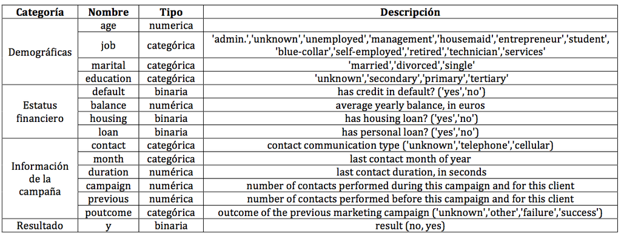

La institución bancaria quisiera conocer como están relacionadas estas variables, en particular, quisieran entender la relación con la variable respuesta *y*.

Utiliza el siguiente código para separar los datos en prueba y entrenamiento:

```r
load("mkt.Rdata")

set.seed(18937)
mkt_train <- sample_n(mkt, 30000)
mkt_test <- anti_join(mkt, mkt_train)
```

### Preguntas

1. **Aprender estructura** (3). Utiliza la muestra de entrenamiento para crear una red bayesiana, si es necesario discretiza o transforma las variables. Si consideras que algunas variables no son relevantes puedes excluirlas del análisis siempre y cuando justifiques tu decisión. Además utiliza la opción blacklist para mejorar la coherencia de la red. Por ejemplo, si pensamos en $y$ como variable respuesta lo más natural sería que no tenga hijos.
- Describe como dscretizaste las variables.
- Explica tu razonamiento para agregar una *whitelist* o *blacklist*.
- Que *score* elegiste para aprender estructura y por que.
2. **Aprender estructura** (3). Con el objetico de crear una red más *robusta*. Genera muestras bootstrap (a partir de los datos de entrenamienti), y calcula una red promedio. Recuerda incluir tu conocimiento experto (*whitelists/blacklists*).
- Describe cuantas muestras usaste y el umbral que usaste para incluir un arco en la red promedio.
- ¿Cuáles on los arcos con mayor *fuerza*?
- Refleja la *fuerza* de los arcos en una gráfica de tu red (usando como medida de fuerza la correspondiente a la función *boot.strength*).
3. **Modelos locales** (2). Una vez que elegiste la estructura final ajusta los modelos locales. Asegurate de que estén bien definidos para todas las variables, es decir, si la estimación de máxima verosimilitud no esta definida para alguna celda (NAs) utiliza un modelo logístico o multinomial o simplemente un suavizamiento de los conteos usando tamaño de muestra imaginaria.
- Justifica tu elección de modelo y parámetros, es decir, si usas tamaño de muestra imagiario que valor usas o si eliges un modelo logístico que interacciones incluyes.
- Substituye las estimaciones en la red por las estimaciones de tus modelos locales.
- Para el nodo correspondiente a $y$ realiza gráficas de las probabilidades ajustadas con tu modelo y comparalas con las correspondientes a máxima verosimilitud.
- Una vez que ajustaste un modelo para el nodo $y$ (con la muestra de entrenamiento) úsalo para predecir el valor de $y$ en la muestra de prueba.  
  Repite las predicciones usando las estimaciones de máxima verosimilitud (nuevamente ajustas el modelo con los datos de entrenamiento y predices sobre los datos de prueba).  
  Puedes usar el *predict* de la función que estás usando en el modelo local (glm, bayesglm, etc.) o predict.grain (ver sección 15 de [tutorial](http://people.math.aau.dk/~sorenh/misc/2012-Oslo-GMwR/GMwR-notes.pdf), una ventaja de usar predict.grain es que puede haber datos faltantes en los predictores y ocupa la evidencia existente y la estructura de la red para predecir las variables de interés).  
  Del conjunto de personas con resultado positivo (*y = yes*) ¿Qué porcentaje clasificas correcto usando cada uno de los dos modelos locales?
4. **Queries de probabilidad condicional** (1). Para estos incisos puedes usar gRain o samiam:
- p(Y=1) =
- p(Y=1|JOB=unemployed, MARITAL=single, EDUCATION=primary) =
- p(JOB=admin.|MARITAL=married, EDUCATION=primary, BALANCE=1000) =
5. **MAP-Maximum a Posteriori** (1). Supón que observas evidencia $E=e$: $e = \{AGE = 20, MARITAL = married, EDUCATION=secondary, DEFAULT=no, BALANCE=1000, MONTH=may, CAMPAIGN = 1\}$ Sea $Y=V$\ $E$, esto es, $Y$ son todas las variables que no están en la evidencia E.
- Para cada variables $Y_i$ en $Y$, ¿cuál es el valor más probable? Es decir,  
  $argmax_{y_i} p(Y_i=y_i|E=e)$
- Calcula los valores $y$ de máxima probabilidad posterior $MAP(Y|E=e)$.
- ¿Coinciden los valores de los incisos anteriores para todas las variables?, ¿Cuál es la diferencia entre los dos métodos?, ¿Cuándo usarías uno u otro?

  Las queries MAP (*maximum a posteriori queries* ó *most probable explanation queries*) consisten en encontrar, como su nombre lo indica, los valores de $Y$ que maximizan la probabilidad posterior. es decir, la probabilidad dada la evidencia E: $MAP(Y|E=e)=argmax_y p(Y=y|E=e)$

**Ejemplo**

En la red de jardín $V=\{Epoca, Llueve, Mojado, Seco, Regar, Piso\_Resbaloso\}$ $e=\{Mojado=seco, Llueve=no\},Y=\{Epoca, Seco, Regar, Piso\_Resbaloso\}$ Observo $P(Piso\_Resbaloso=normal|E)$: $p(Piso\_Resbaloso=normal|E=e)=0.8, p(Piso\_Resbaloso=muy\_resbaloso|E=e)=0.05$ $p(Piso\_Resbaloso=resbaloso|E)=0.15$ y por tanto para $Y_i=Piso\_Resbaloso$, el valor más probable es $y_i=normal$.

[figure not shown]

Para calcular los valores que maximizan la probabilidad posterior (MAP), selecciona la evidencia en las tablas de probabilidad condicional y presiona el botón MAP, en la ventana se elige Aproximate o Exact (yo seleccioné Exact) y se presiona Update.

En el caso de la red jardín MAP(Y|E=e) nos da $y=(invierno, normal, apagado)$ que coincide con los valores individualmente más probables.

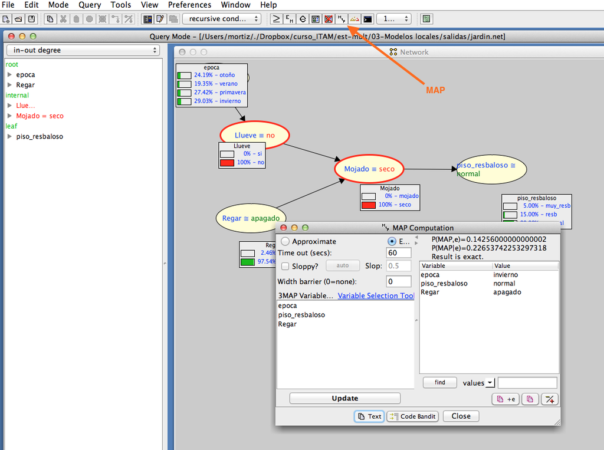

**Nota:** El problema de eliminar ruido de una imagen es un caso de queries MAP que resolvimos usando ICM.

**No he dado ni recibido ayuda no autorizada en la realización de este exámen.**

Firmas